# Practical Machine Learning Project

Frank F.

Thursday, June 18, 2015

### Purpose

The goal of this project is to build a statistic model to predict the manner (“classe” variable in the dataset) of exercise performed by a group using the data collected from sensors attached to the individuals in the group.

### Data description

The data used in this project come from http://groupware.les.inf.puc-rio.br/har. It contains the measurements of six young health participants performing one set of 10 repetitions of the Unilateral Dumbbell Biceps Curl in five different fashions: exactly according to the specification (Class A), throwing the elbows to the front (Class B), lifting the dumbbell only halfway (Class C), lowering the dumbbell only halfway (Class D) and throwing the hips to the front (Class E). The details description of data can be found in the reference article.

### Reading the data

After downloading the data files from the project source links into a R studio work directory, importing the training and testing data files into data frames:

```r
pml_training<-read.csv("pml-training.csv",na.strings=c("NA",""))
pml_testing<-read.csv("pml-testing.csv",na.strings=c("NA",""))
```

### Exploring and cleaning data

Take a look of summary of the data:

```r
summary(pml_training)
```

[output not shown]

Remove variables with most of observations are NAs:

```r
dim(pml_training)
```

```
## [1] 19622   160
```

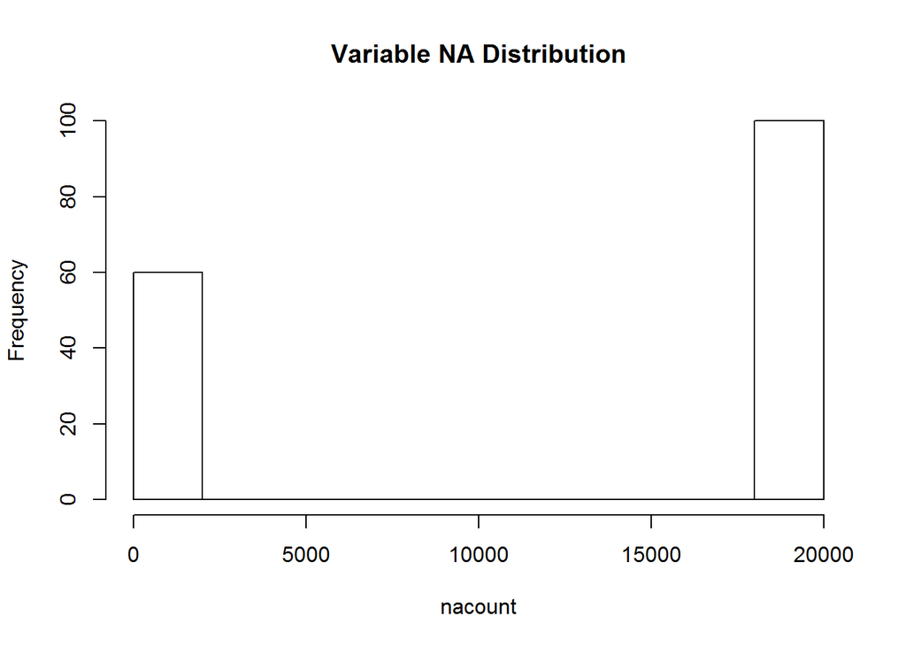

```r
#count NAs
nacount<-sapply(pml_training,function(x) sum(is.na(x)))
#plot the NAs distribution
hist(nacount,main="Variable NA Distribution")
```

```r
#find the most NA count value in the histogram
varnas <- max(nacount)
#remove columns with most of NAs
pml_training <- pml_training[,colSums(is.na(pml_training))<varnas]
dim(pml_training)
```

```
## [1] 19622    60
```

Finding the near zero variance variables:

```r
library(caret)
nzvdf<-nearZeroVar(pml_training,saveMetrics=TRUE)
```

```r
# show the varibales with near zero variance
nzvdf[nzvdf$nzv==TRUE,]
```

```
##            freqRatio percentUnique zeroVar  nzv
## new_window  47.33005    0.01019264   FALSE TRUE
```

```r
#check a sample of variable types and values
str(pml_training[,1:12])
```

```
## 'data.frame':    19622 obs. of  12 variables:
##  $ X                   : int  1 2 3 4 5 6 7 8 9 10 ...
##  $ user_name           : Factor w/ 6 levels "adelmo","carlitos",..: 2 2 2 2 2 2 2 2 2 2 ...
##  $ raw_timestamp_part_1: int  1323084231 1323084231 1323084231 1323084232 1323084232 1323084232 1323084232 1323084232 1323084232 1323084232 ...
##  $ raw_timestamp_part_2: int  788290 808298 820366 120339 196328 304277 368296 440390 484323 484434 ...
##  $ cvtd_timestamp      : Factor w/ 20 levels "02/12/2011 13:32",..: 9 9 9 9 9 9 9 9 9 9 ...
##  $ new_window          : Factor w/ 2 levels "no","yes": 1 1 1 1 1 1 1 1 1 1 ...
##  $ num_window          : int  11 11 11 12 12 12 12 12 12 12 ...
##  $ roll_belt           : num  1.41 1.41 1.42 1.48 1.48 1.45 1.42 1.42 1.43 1.45 ...
##  $ pitch_belt          : num  8.07 8.07 8.07 8.05 8.07 8.06 8.09 8.13 8.16 8.17 ...
##  $ yaw_belt            : num  -94.4 -94.4 -94.4 -94.4 -94.4 -94.4 -94.4 -94.4 -94.4 -94.4 ...
##  $ total_accel_belt    : int  3 3 3 3 3 3 3 3 3 3 ...
##  $ gyros_belt_x        : num  0 0.02 0 0.02 0.02 0.02 0.02 0.02 0.02 0.03 ...
```

From the above results of data structure, distribution summary, and variance calculations, we can see column X is a sequence number, new_window has near zero variance. While we are only interested to classify the manner of exercise, the individual identity and time information should not play a role in our prediction, so we can remove columns 1-6 from our training set.

```r
pml_training<- pml_training[,-(1:6)]
dim(pml_training)
```

```
## [1] 19622    54
```

```r
table(pml_training$classe)
```

```
##
##    A    B    C    D    E
## 5580 3797 3422 3216 3607
```

### Building Model

We can see the training data set is rather large, we will split the data set into two halves, each contains 50% of data set, one will be used for training the model, and the other will be used for cross validation and calculation of out-of-sample error. As indicated in the reference article, we will use random forest method to classify the different manner of exercise (classe), and we will use k-fold cross-validation (cv) as train control options to minimize in-sample errors, and we choose k=5 in order to save computer time to train the model. Here are the steps and training results:

```r
set.seed(201506)
inTrain <-createDataPartition(y=pml_training$classe,p=0.5,list=FALSE)
trainData <-pml_training[inTrain,]
validData <-pml_training[-inTrain,]
# use k-fold cross-validation method in train control option
trControl <- trainControl(method = "cv", number = 5,allowParallel=TRUE)
# perform training using random forest method
rfFit <- train(trainData$classe ~ ., method = "rf", trControl = trControl, data =trainData)
#final model
rfFit$finalModel
```

```
##
## Call:
##  randomForest(x = x, y = y, mtry = param$mtry)
##                Type of random forest: classification
##                      Number of trees: 500
## No. of variables tried at each split: 27
##
##         OOB estimate of  error rate: 0.3%
## Confusion matrix:
##      A    B    C    D    E  class.error
## A 2789    1    0    0    0 0.0003584229
## B    4 1890    3    2    0 0.0047393365
## C    0    8 1703    0    0 0.0046756283
## D    0    0    7 1600    1 0.0049751244
## E    0    1    0    2 1801 0.0016629712
```

```r
# model fit accuracy
acy<-rfFit$results$Accuracy[2]
```

From the training finalModel, we obtained estimated OOB ,or out of bag (sample) error is 0.3% and predication accuracy for the training set is 0.9954129. The plots below shows the out of bag error rate for each classes vs trees. the black solid line in the middle is the overall out of bag error.

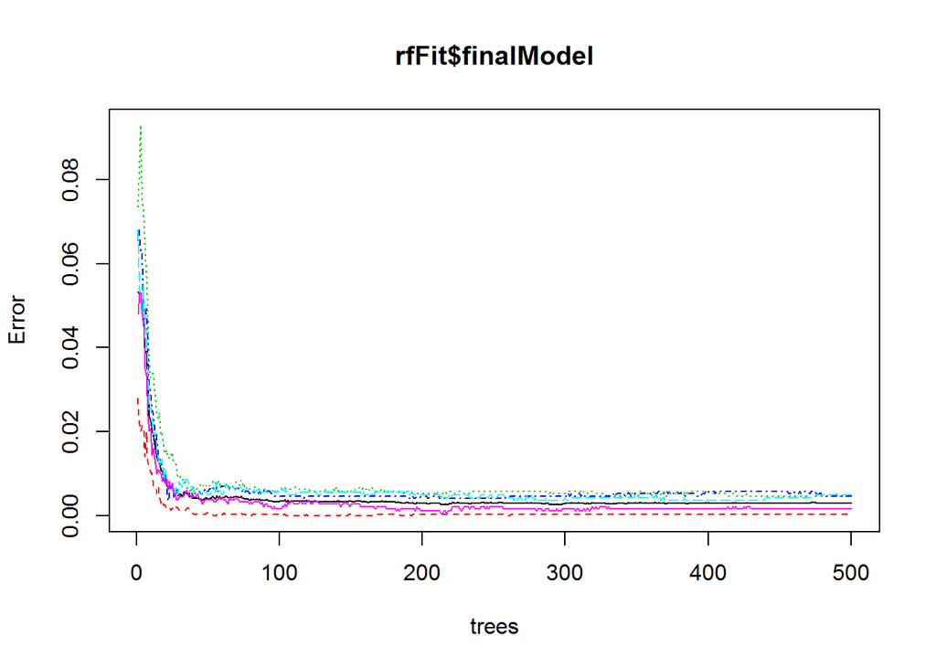

```r
plot(rfFit$finalModel)
```

### Cross-Validation and out-of-sample error

Applying the model to the other half of the training data set we hold out to cross validate the model, we can test our prediction accuracy and calculate the out-of-sample error.

```r
# predict with the other half of the training data .
prediction_valid<-predict(rfFit,newdata=validData)
# over all accuracy
oacy<-confusionMatrix(prediction_valid,validData$classe)$overall[1]
# the out of sample error
osmpl_err<-1-oacy
```

We found overall predication accuracy for the validation set is 0.9972477 which means we did not over fit or under fit the model, or the split-ed datasets are very similar. The out-of-sample error is 0.0027523 which is very close to the model estimated OOB error 0.3% from the k-fold cross-validation training control, which indicates the OOB error is as accurate as out-of-sample error we calculated using a validation set of the same size as the training set used to build the model.

### Test data predication

Now we can apply our model to the testing data set and write out answers into individual files for our second part of the project.

```r
# remove NA columns
pml_testing<-pml_testing[,colSums(is.na(pml_testing))<20]
# remove first six columns
pml_testing <-pml_testing[,-(1:6)]
# predications for test data
answers <- predict(rfFit,newdata=pml_testing)
answers
```

```
##  [1] B A B A A E D B A A B C B A E E A B B B
## Levels: A B C D E
```

```r
#write answer to files use a function
pml_write_files = function(x){
     n = length(x)
     for(i in 1:n){
         filename = paste0("problem_id_",i,".txt")
         write.table(x[i],file=filename,quote=FALSE,row.names=FALSE,col.nam=FALSE)
     }
 }
pml_write_files(answers)
```

### Reference

Velloso, E.; Bulling, A.; Gellersen, H.; Ugulino, W.; Fuks, H. Qualitative Activity Recognition of Weight Lifting Exercises. Proceedings of 4th International Conference in Cooperation with SIGCHI (Augmented Human ’13) . Stuttgart, Germany: ACM SIGCHI, 2013.